# The Act Of Data Wrangling

## Outline

#### 1. Introduction

#### 2. Steps Involved During Data Wrangling

#### 3. Case Study: Dog Rate Data Wrangle

#### 4. Insights from Case Study

## 1. Introduction

Data Wrangling could be seen as the process of cleaning and unifying messy and complex datasets for easy access and analysis. This can also be known as data munging, which involves the process of cleaning, organizing, and transforming raw data into desired format for proper decision making.

Data Wrangling does not have a one way rule, it is usually dependent on the data being worked on. Research shows professionals spend about 80% of their time in data wrangling, while the remaining 20% can be used for exploration and modelling.

The act of Data wrangling has been of great benefits to data analyst. Data wranging help does the following:

- Make raw data usable
- Centralizes data from several sources and location
- It acts as the preparation stage for data mining
- Cleansing of data from noise and flaws
- Helps for concrete business decisions

## 2. Steps Involved During Data Wrangling

The steps involved during the act of data wrangling can be summarized in to five. They include:

1. Data Gathering
2. Accessing Data
3. Data Cleaning
4. Data Storage
5. Others (Analysis & Visualizations)

These steps are not rigid, they could be changed depending on the data involved.

#### 1. Data Gathering

Data gathering is also known as data collection. It is the process of gathering and measuring information on targeted variables in an established system. It involves the collection of data from several sources for the purpose of analyzing the data and driving insights from the data.

During Data wrangling, data gathering can be done in several ways and format. But for the purpose of this act, I will be limiting the my discussion to three basic method of gathering data, They include:

1. Downloading Dataset manually (using in .csv format)
2. Programmatically downloading of data, using the python request library
3. The Use of APIs to scrap data

These methods are solely dependent on the analyst involved, the nature of the data and the problem to be solved

#### 2 Accessing Data

Accessing Data is a step in the data wrangling act which involves the process of scanning, perusing and thoroughly checkin the datasets gathered. The data is being check to sort for errors and other irregularities related to the data. Accessing of data can be done:

- Visually - involves scrolling through the data to check for irregularities. &
- Programmatically - This involves the use of codes to check for errors associated with the data

We access data to check for the quality and how tidy the data is. This is subject to the persons involved in the data acessing process.

#### 3. Data Cleaning

After Accessing the data and fetching out the irregularities with the datasets, it is expedient that those issues be handled. This step is very important as it will be keep the quality of the datasets and keep the data tidy, and ready for storage and further analysis. The method of data cleaning is relative to the issues encountered and the analyst creativity and exposure

#### 4. Data Storage

At this stage, your data is ready to be stored for further analysis. The Storage of the data is where you select which table is to be added and which is not relevant. It is preferred the master data to be stored in data.cvs format for easy interaction with pandas DataFrame.

## 3. Case Study: Dog Rate Data Wrangle

This is a case study of data wrangling. The dataset used in this project is a twitter archive user @dog_rates, also known as WeRateDogs. WeRtaeDogs is a twitter account that rates dogs with humorous comments about the dog.

Aim: In this project, I was expected to apply the steps listed above to wrangle this data and come up with at least three insights.

So let's start right away;

#### I. Data Gathering

Here, I gathered data three different data format for the project as required. I applied the following methods in gathering the data.

1. Manual Download (.csv data)- This data was downloaded manually and loaded into pandas DataFrame.
2. request library- I used the request library to access and download data from the url given.

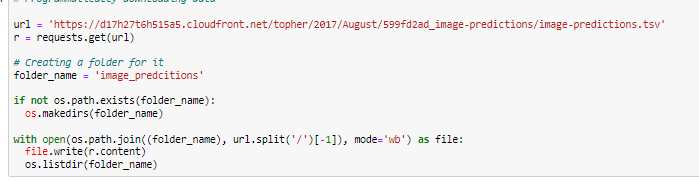

3. API - The twitter API used for this project is the tweepy. This API allows for the scrapping of data from twitter. But your request must be first approved, before proceeding.

#### II. Accessing Data

In accessing the data I was able to spot out eight quality issues which are peculiar to this data and two tidiness issues. Remember, this step is soley dependent on the analyst involoved. Below is a snippet of the issues related to this data

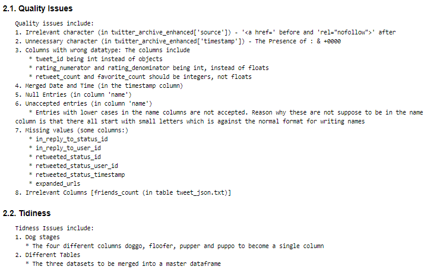

#### III. Data Cleaning

During Data cleaning, I was able to address the several issues listed above. There is a unique method I employed during cleaning data, it involves; defining the issue in a written format, coding the problem, & Testing the solution. Below is the solution to the issues

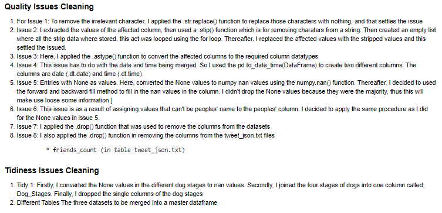

#### IV. Data Storage

After the whole cleaning process, I merged the three datasets together. That resulted to a master DataFrame. below is a snippet for how to merged three DataFrame together

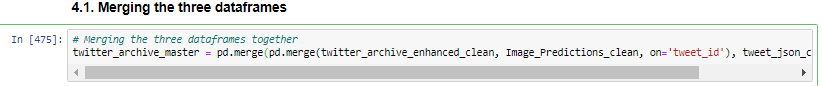

After the merging, the master data was then saved to a .csv format

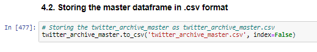